# Презентация по лабораторной работе №4

Реализация основных моделей в агентном подходе

Люпп Софья Романовна

1132236039@rudn.ru

Российский университет дружбы народов

2026-04-01

# Информация

## Докладчик

- Люпп Софья Романовна
- стундентка группы НКНбд-01-23
- кафедра теории вероятностей и кибербезопасности
- Российский университет дружбы народов им. П. Лумумбы
- 1132236039@rudn.ru
- https://github.com/srluipp

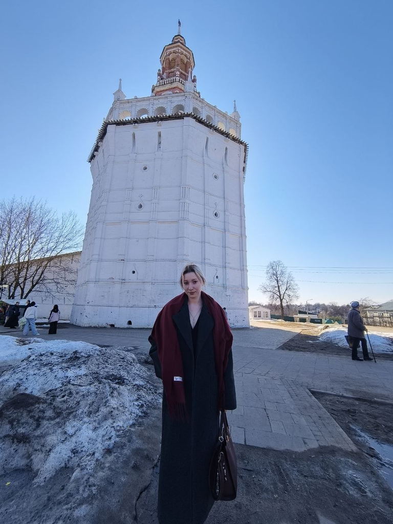

# Вводная часть

## Актуальность

Модель SIR остаётся одним из фундаментальных инструментов в эпидемиологии, позволяя оценивать динамику распространения инфекций в популяциях.

## Объект и предмет исследования

Объектом исследования является агентный подход. Предметом исследования является модель SIR

## Цели

Изучить модель SIR, применить агентный подход к моделированию

## Задачи

1. Создать и запустить программный код скриптов с описанием модели SIR;
2. Выполнить практическое задание в конце лабораторной работы.
3. Оформить документацию в формате Quarto, преобразовать в литературный стиль.

## Материалы и методы

В качестве материалов к выполнению лабораторной работы была использована работа Имитационное моделирование. Практикум. (А. В. Королькова Кулябов Д. С.)

# Выполнение лабораторной работы

## Статистика по SIR

На графике выведена статистика по всем группам модели - восприимчивые, инфицированные и выздоровевшие. Так же на графике представлена и статистика общего количества людей в течение 100 дней (рис. 1)

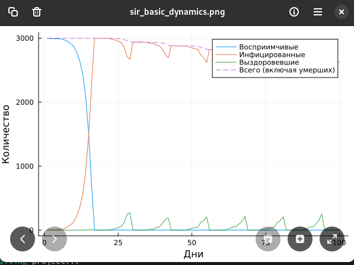

Рисунок 1: Статистика по количеству S, I, R

## Доля инфицированных

На графике представлена доля инфецированных людей в зависимости от коэффициента заразности, отмечая пик эпидемии, конечную долю инфицированных и долю умерших(рис. 2).

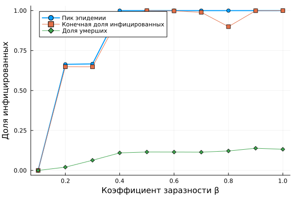

Рисунок 2: Доля инфицированных от количества заразности

## Влияние миграции на скорость распространение инфекции

На графике показываем, как интенсивность перемещения людей между городами влияет на скорость распространения эпидемии и масштаб пика, при условии, что инфекция начинается только в одном городе, а остальные изначально здоровы (рис. 3)

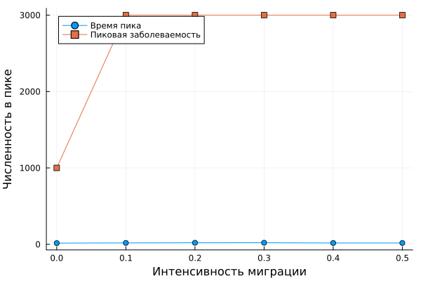

Рисунок 3: Численность людей в пике от интенсивности миграции

## Оптимальные параметры

Получаем вывод в консоль об оптимальных параметрах, минимизирующих пиковую заболеваемость и долю умерших. Среди них: время выявление, смертность, порог бета и другие. (рис. 4).

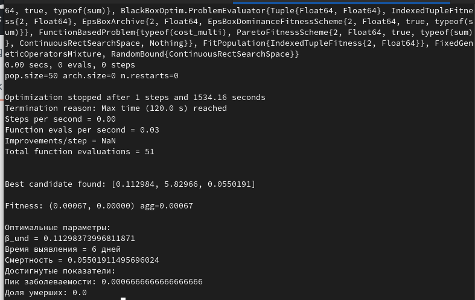

Рисунок 4: Вывод оптимальных параметров

## Сводный график

Выводим общий график для всех групп - инфициронных, умерших и выздоровевших от интенсивности заражения бета (рис. 5).

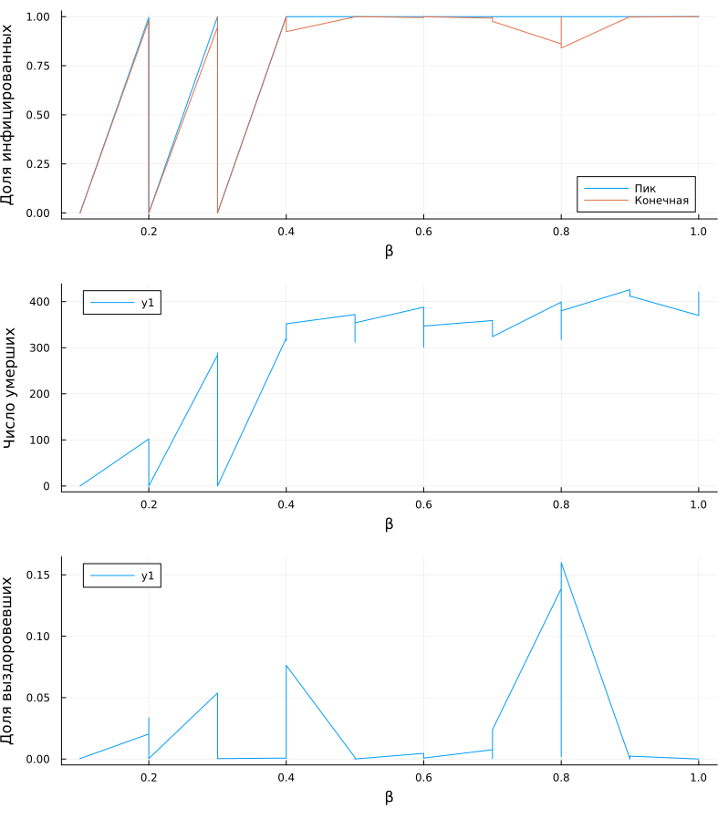

Рисунок 5: Итоговый отчет comprehensive_analysis.png

## Задание №1

Построила график динамики численности для S, I, R. Базовое репродуктивное число R0 получилось равным 4.2, > 1 (рис. 6).

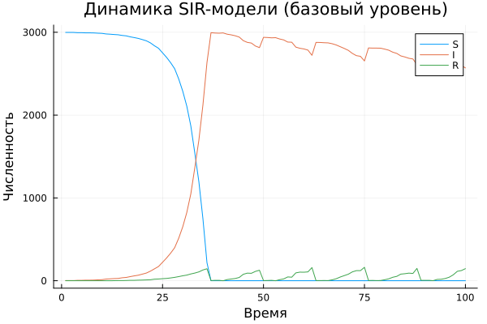

Рисунок 6: Получившийся график задания 1

## Задание №2

Получили вывод в консоль по заданиям 1-6. Минимальный порог бета (интенсивности заражения) составляет 0.17. Теоретический порог для базового репродуктивного числа =1 составил бета равное примерно 0.07 (рис. 7)

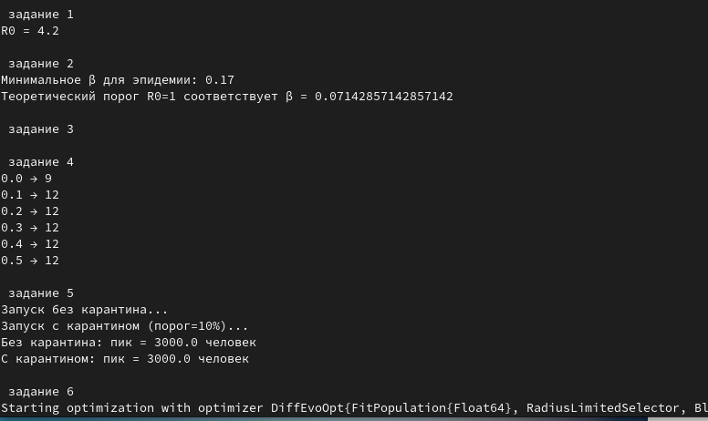

Рисунок 7: Полученные выводы в консоль для заданий 1-5

## Задание №3

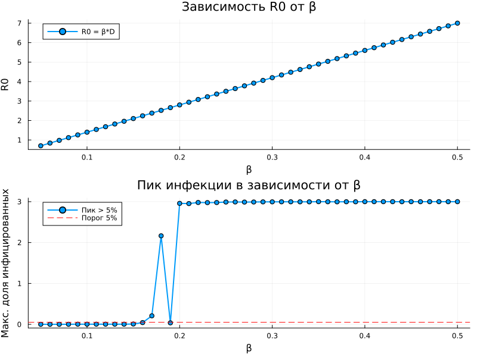

## Задание №4

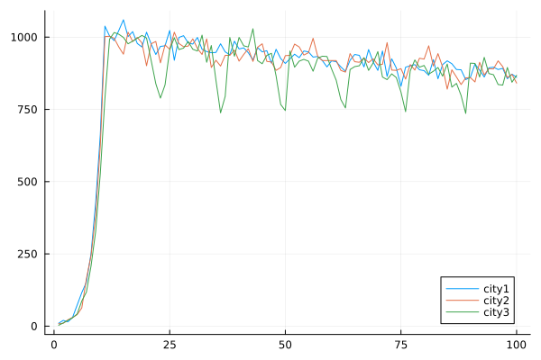

Рисунок 9: График миграции

## Задание №5

Модифицируеи модель, добавив возможность закрытия города (обнуление миграции из него) при превышении порога заболеваемости. Результаты получились примерно одинаковыми (рис. 10).

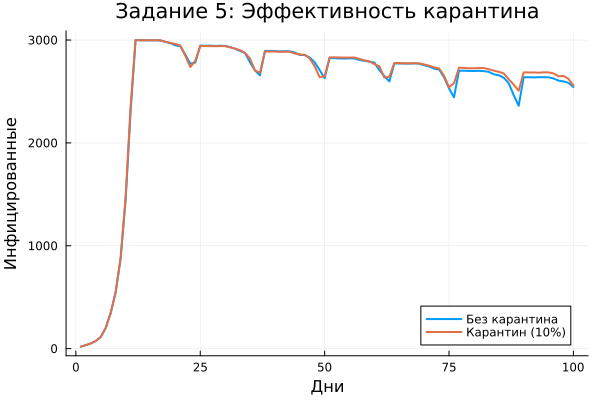

Рисунок 10: Карантинные меры

## Задание №6

Используя оптимизацию, находим параметры, которые минимизируют общее число умерших при сохранении пика заболеваемости ниже 30%(рис. 11)

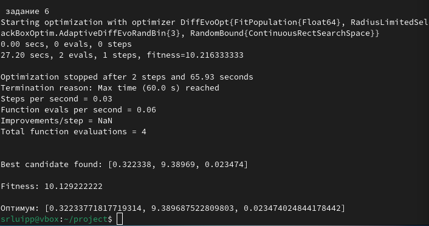

Рисунок 11: Вывод оптимальных параметров

## Результаты

Результатами лабораторной работы явялются представленные графики моделирования SIR.

## Итоговый слайд

В результате лабораторной работы я изучила агентный подход к моделированию и поработала с моделью SIR

(рис. 12)

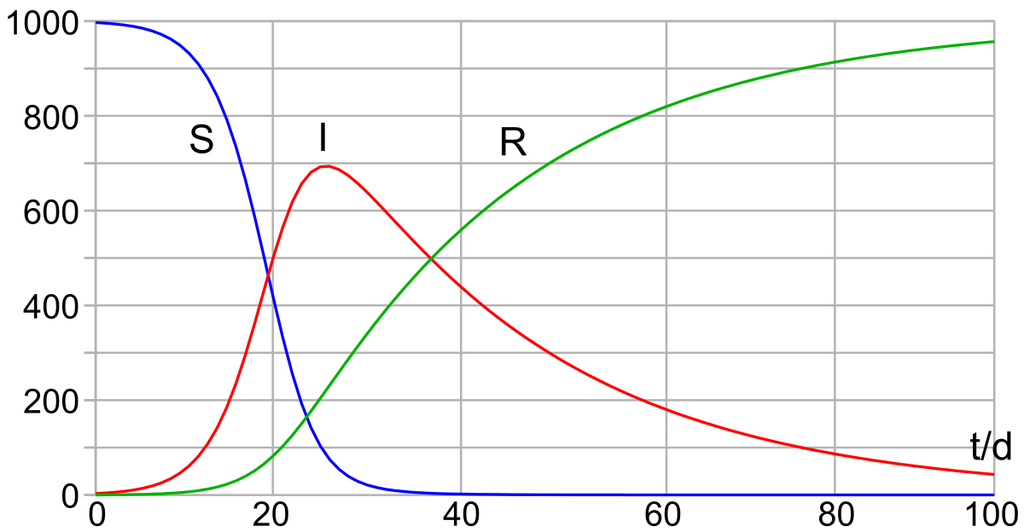

Рисунок 12: SIR model